# Análisis de Portafolio

Leonardo Moreno López

2023-04-09

Con este trabajo buscare aplicar a la realidad lo que es la Teoría de Portafolio moderna de Harry Markowitz (1952) que intenta de maximizar el retorno de un portafolio y minimizar el riesgo medido a través de el estadistico de la desviación estandar. Para esto utilizare 15 activos riesgosos como lo son las acciones de algunas de las siguientes compañias: Apple Inc. (AAPL), The Boeign Company (BA), Caterpillar Inc. (CAT), International Business Machines Corporation (IBM), JPMorgan Chase & Co. (JPM), que estan incertas en distintos índices de mercado norteamericano como lo son el NASDAQ y el NYSE. Trabajaré con paquetes tales como lo son “tidquant” para descargar datos desde Yahoo Finances, “xts” para trabajar con series de tiempo, “PerformanceAnalytics” para trabajar con lo que es la Teoría de Portafolío y “tseries” para encontrar el portafolio óptimo.

Para partir, descargare los datos historicos de cada una de las acciones desde el 01-01-1980 hasta el 01-01-2023 pero en realidad trabajare desde el 01-12-2000 hasta el 31-12-2022 ya que algunas de las compañias hicieron su IPO (Oferta Pública Inicial) posterior al 01-01-1980.

```r
#Importando datos
AAPL<- tq_get("AAPL", get = "stock.prices", from="1980-01-01", to="2023-01-01",
              periodicity="daily")
AAPL$date <- as.Date(AAPL$date)
AAPL <- as.xts(AAPL)
AAPL <- AAPL[,7]
colnames(AAPL)[1] <- "AAPL"
AAPL <- window(AAPL, start = "2000-12-01", end ="2022-12-31")

#Amazon.com Inc.
AMZN<- tq_get("AMZN", get = "stock.prices", from="1980-01-01", to="2023-01-01",
              periodicity="daily")
AMZN$date <- as.Date(AMZN$date)
AMZN <- as.xts(AMZN)
AMZN <- AMZN[,7]
colnames(AMZN)[1] <- "AMZN"
AMZN <- window(AMZN, start = "2000-12-01", end ="2022-12-31")

# The Boeing Company
BA <- tq_get("BA", get = "stock.prices", from="1980-01-01", to="2023-01-01",
              periodicity="daily")
BA$date <- as.Date(BA$date)
BA <- as.xts(BA)
BA <- BA[,7]
colnames(BA)[1] <- "BA"
BA <- window(BA, start = "2000-12-01", end ="2022-12-31")

#Caterpillar Inc.
CAT <- tq_get("CAT", get = "stock.prices", from="1980-01-01", to="2023-01-01",
              periodicity="daily")
CAT$date <- as.Date(CAT$date)
CAT <- as.xts(CAT)
CAT <- CAT[,7]
colnames(CAT)[1] <- "CAT"
CAT <- window(CAT, start = "2000-12-01", end ="2022-12-31")

#The Walt Disney Company
DIS <- tq_get("DIS", get = "stock.prices", from="1980-01-01", to="2023-01-01",
              periodicity="daily")
DIS$date <- as.Date(DIS$date)
DIS <- as.xts(DIS)
DIS <- DIS[,7]
colnames(DIS)[1] <- "DIS"
DIS <- window(DIS, start = "2000-12-01", end ="2022-12-31")

#General Electric Company
GE <- tq_get("GE", get = "stock.prices", from="1980-01-01", to="2023-01-01",
              periodicity="daily")
GE$date <- as.Date(GE$date)
GE <- as.xts(GE)
GE <- GE[,7]
colnames(GE)[1] <- "GE"
GE <- window(GE, start = "2000-12-01", end ="2022-12-31")

#HP Inc.
HPQ <- tq_get("HPQ", get = "stock.prices", from="1980-01-01", to="2023-01-01",
              periodicity="daily")
HPQ$date <- as.Date(HPQ$date)
HPQ <- as.xts(HPQ)
HPQ <- HPQ[,7]
colnames(HPQ)[1] <- "HPQ"
HPQ <- window(HPQ, start = "2000-12-01", end ="2022-12-31")

#International Business Machines Corporation
IBM <- tq_get("IBM", get = "stock.prices", from="1980-01-01", to="2023-01-01",
              periodicity="daily")
IBM$date <- as.Date(IBM$date)
IBM <- as.xts(IBM)
IBM <- IBM[,7]
colnames(IBM)[1] <- "IBM"
IBM <- window(IBM, start = "2000-12-01", end ="2022-12-31")

#Johnson & Johnson
JNJ <- tq_get("JNJ", get = "stock.prices", from="1980-01-01", to="2023-01-01",
              periodicity="daily")
JNJ$date <- as.Date(JNJ$date)
JNJ <- as.xts(JNJ)
JNJ <- JNJ[,7]
colnames(JNJ)[1] <- "JNJ"
JNJ <- window(JNJ, start = "2000-12-01", end ="2022-12-31")

#JPMorgan Chase & Co.
JPM <- tq_get("JPM", get = "stock.prices", from="1980-01-01", to="2023-01-01",
              periodicity="daily")
JPM$date <- as.Date(JPM$date)
JPM <- as.xts(JPM)
JPM <- JPM[,7]
colnames(JPM)[1] <- "JPM"
JPM <- window(JPM, start = "2000-12-01", end ="2022-12-31")


#The Coca-Cola Company
KO <- tq_get("KO", get = "stock.prices", from="1980-01-01", to="2023-01-01",
              periodicity="daily")
KO$date <- as.Date(KO$date)
KO <- as.xts(KO)
KO <- KO[,7]
colnames(KO)[1] <- "KO"
KO <- window(KO, start = "2000-12-01", end ="2022-12-31")

#McDonald´s Corporation
MCD <- tq_get("MCD", get = "stock.prices", from="1980-01-01", to="2023-01-01",
              periodicity="daily")
MCD$date <- as.Date(MCD$date)
MCD <- as.xts(MCD)
MCD <- MCD[,7]
colnames(MCD)[1] <- "MCD"
MCD <- window(MCD, start = "2000-12-01", end ="2022-12-31")

#Microsoft Corporation

MSFT <- tq_get("MSFT", get = "stock.prices", from="1980-01-01", to="2023-01-01",
              periodicity="daily")
MSFT$date <- as.Date(MSFT$date)
MSFT <- as.xts(MSFT)
MSFT <- MSFT[,7]
colnames(MSFT)[1] <- "MSFT"
MSFT <- window(MSFT, start = "2000-12-01", end ="2022-12-31")

#Nike Inc.
NKE <- tq_get("NKE", get = "stock.prices", from="1980-01-01", to="2023-01-01",
              periodicity="daily")
NKE$date <- as.Date(NKE$date)
NKE <- as.xts(NKE)
NKE <- NKE[,7]
colnames(NKE)[1] <- "NKE"
NKE <- window(NKE, start = "2000-12-01", end ="2022-12-31")

#Walmart Inc.
WMT <- tq_get("WMT", get = "stock.prices", from="1980-01-01", to="2023-01-01",
              periodicity="daily")
WMT$date <- as.Date(WMT$date)
WMT <- as.xts(WMT)
WMT <- WMT[,7]
colnames(WMT)[1] <- "WMT"
WMT <- window(WMT, start = "2000-12-01", end ="2022-12-31")
```

Lo que hice anteriormente fue descargar los precios historicos de cada una de las acciones y a cada una de las bases de datos las nombre con su ticker correspondiente. Luego la columna Date de cada base de datos la asgine como fecha, elimine el resto de columnas y solo deje aquellas que me servian para trabajar en esto que eran Date y la de Precio Ajustado, a esta última, la nombre con el ticker de cada acción. Finalmente filtre con aquellas fechas que voy a trabajar. A modo de ejemplo visualizare los primeros 5 datos de la base de datos correspondiente a Walmart para ver el resultado de esto.

```r
head(WMT, 5)
```

```
##                   WMT
## 2000-12-01  33.857456
## 2000-12-04  35.593716
## 2000-12-05  36.544548
## 2000-12-06  36.255173
## 2000-12-07  36.379200
```

A continuación junte las 15 bases de datos en una y nombre a esta “Prices”, su nombre lo dice, son los precios historicos de cada una de las 15 acciones.

La base de datos Prices en un archivo xts, es decir, en simples palabras, es una serie de tiempo pero las columnas deberían ser reconocidas como datos numericos pero en realidad son datos tipo caracter por lo siguiente que hare es modificar la clase de estos datos a numerico. Para esto, convertire Prices en un data frame para poder realizar lo anteriormente mencionado y una vez que todos los datos sean clase numerica, convertiré de nuevo esta base de datos en un archivo xts.

Lo siguiente a realizar sera calcular el retorno logaritmico mensual de cada uno de estos 15 activos. Para esto primero calculare el retorno diario y eliminaré el los primeros datos pertenecientes a la primera fila ya que no existen registros de precios anterior a la fecha inicial. Una vez obtenidos estos retornos diarios, procederé a calcular los retornos mensuales.

```r
#Retornos historicos de activos por separados
Retornos <- Return.calculate(Prices, method ="log")
DRetornos <- Retornos[-1,]
MRetornos <- to.monthly(DRetornos, OHLC = FALSE, indexAt = "lastof")
MRetornos <- round(MRetornos, digits= 4)
head(MRetornos,3)
```

```
##               AMZN    AAPL      BA     CAT     DIS      GE     HPQ     IBM
## 2000-12-31 -0.1102  0.0042  0.0086 -0.0066  0.0065 -0.0104 -0.0273 -0.0029
## 2001-01-31 -0.0897 -0.0058  0.0410 -0.0041 -0.0147 -0.0059 -0.0255 -0.0403
## 2001-02-28 -0.1427 -0.0598 -0.0238 -0.0212  0.0065 -0.0317  0.0087 -0.0266
##               JNJ     JPM      KO     MCD    MSFT     NKE     WMT
## 2000-12-31 0.0030 -0.0325 -0.0020  0.0037 -0.0270 -0.0167  0.0035
## 2001-01-31 0.0166 -0.0178  0.0016 -0.0034 -0.0372  0.0370  0.0548
## 2001-02-28 0.0143 -0.0199  0.0196 -0.0219 -0.0063 -0.0089 -0.0178
```

Ahora visualizaremos algunas de las series de retornos pertenecientes a estas acciones.

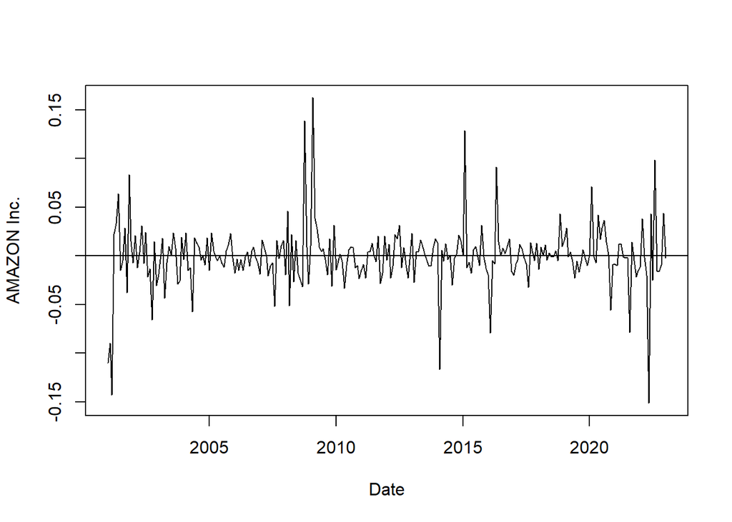

```r
#Gráficos de los retornos individuales
#Amazon.com Inc.
plot.zoo(MRetornos$AMZN, ylab= "AMAZON Inc.", xlab = "Date")
abline(h=0)
```

Lo importante a mencionar de Amazón es que registra tres caidas significantes en sus retornos. La primera de ellas es a principios de siglo donde se puede observar que tiene retornos negativos cerca de un 0,15%. Luego, entre los años 2010 y 2015 se observa que sobre pasa por muy poco el 0,1% de retorno negativo y por último, después del año 2020, aproximadamente en el año 2022, se observa la última caida significatica de sus retornos sobrepasando por muy poco el 0,15%. Como retornos negativos significativos también podemos visualizar retornos que son significativos positivamente hablando. Cerca del año 2010 podemos ver que hay dos importantes alzas en sus retornos alcanzando el 0,15%. Por último,omenzando el año 2015 también se ve un alza en sus retornos sobrepasando el 0,1%.

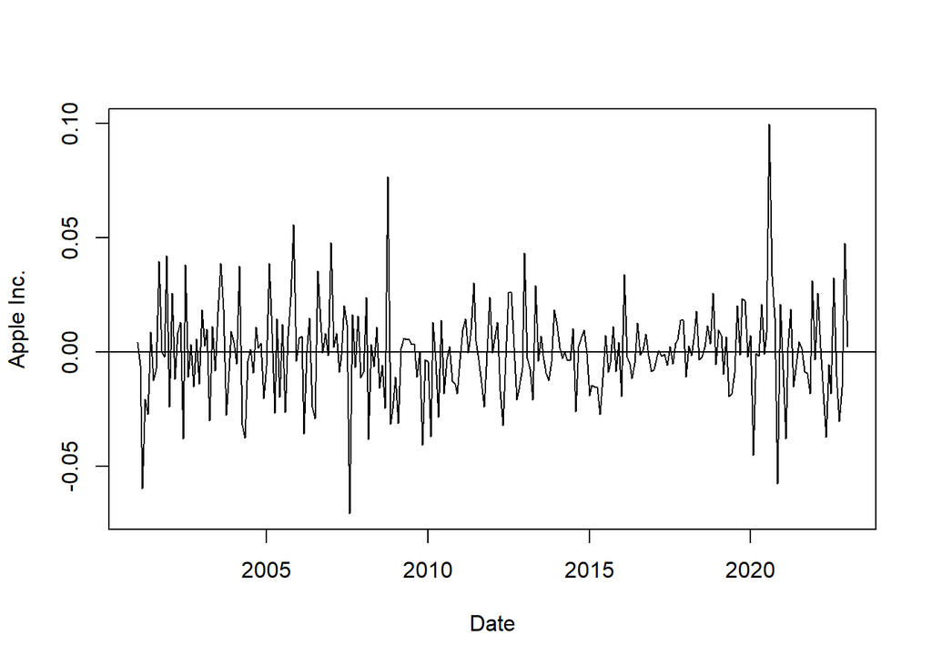

```r
#Apple Inc.
plot.zoo(MRetornos$AAPL, ylab = "Apple Inc.", xlab="Date")
abline(h=0)
```

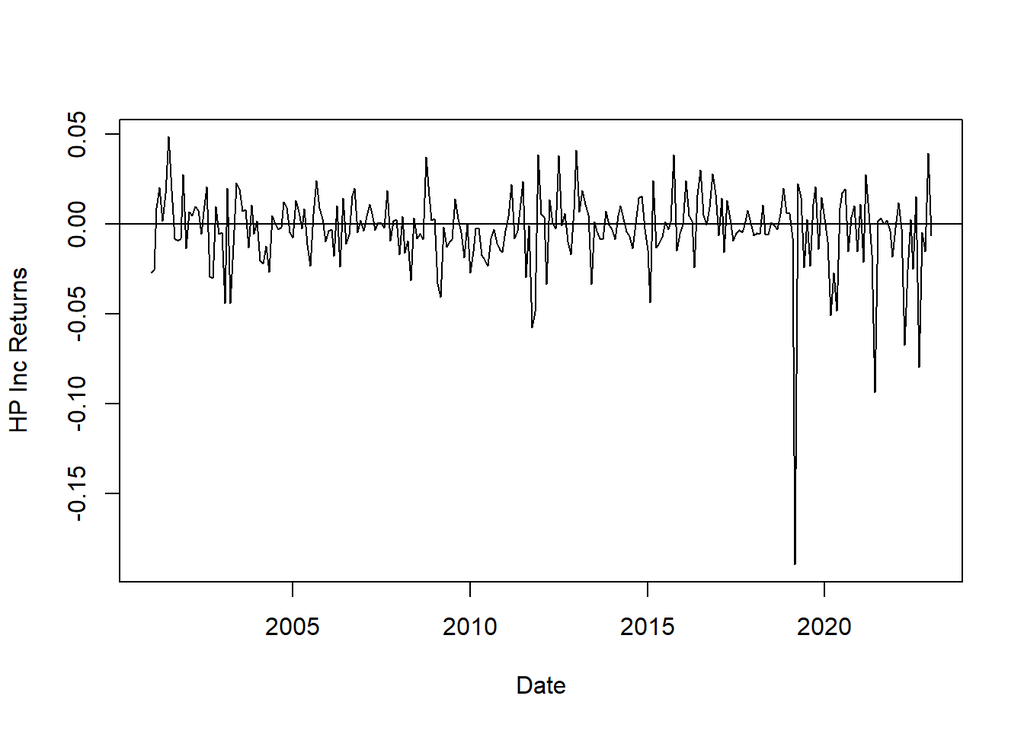

```r
#HP Inc.
plot.zoo(MRetornos$HPQ, ylab = "HP Inc Returns", xlab="Date")
abline(h=0)
```

Como se puede observar del gráfico anterior, HP Inc. cerca del año 2020 registra una caida importante en sus retornos, sobrepasando el 0,15% negativamente hablando.

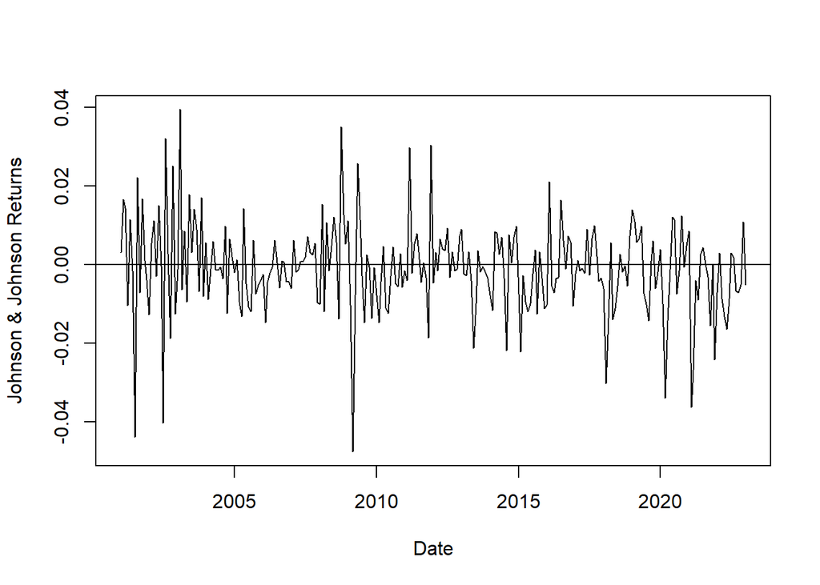

```r
# #Johnson & Johnson
plot.zoo(MRetornos$JNJ, ylab = "Johnson & Johnson Returns", xlab="Date")
abline(h=0)
```

Johnson & Johnson a lo largo de esta ventana de tiempo ha tenido tres caidas importantes de sus retornos. Las primeras de ellas se registran entre los años 2000 y 2005 sobrepasando el 0,04% en primera instancia y en segundo lugar rozando el 0,04%. Por último, la tercera caída importante se registra cerca del año 2010, con una caída que sobrepasa el 0,04%. Dentro de las alzas importantes, podemos mencionar una o dos ocasiones, la primera de ellas, se registra entre los años 2000 y 2005, alcanzado el 0,04% de retorno y el segundo registro importante se ocasiona justo antes de la caída más importante de sus retornos, registrando un retorno de 0,04% aproximadamente.

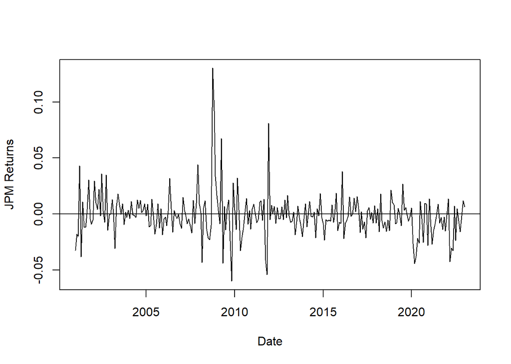

```r
#JPM
plot.zoo(MRetornos$JPM, ylab = "JPM Returns", xlab="Date")
abline(h=0)
```

Por un lado, JPMorgan Chase & Co. no regitra importantes caídas de sus retornos a través de esta ventana de tiempo. Se podría destacar aquella en que registra su peor rendimiento cerca del año 2010, registrando un 0,05% negativamente hablando. Por otro lado, tampoco registra alzas importantes de sus rendimientos, salvo por 2 ocasiones, la primera de ella es entre los años 2005 y 2010, donde sobrepasa el 0,1% de rendimiento y la segunda vez, es entre los años 2010 y 2015, obteniendo un 0,07% aprox.

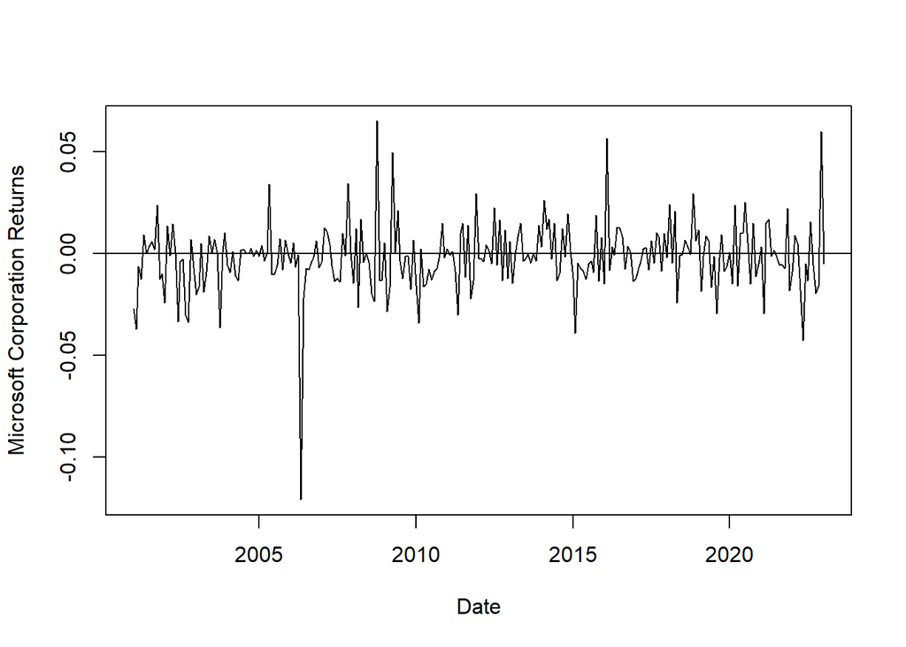

```r
#MSFT
plot.zoo(MRetornos$MSFT, ylab = "Microsoft Corporation Returns", xlab="Date")
abline(h=0)
```

Microsoft Corporation por su parte, no registra grandes caidas en sus rendimientos a excepción de aquella que se registra en el año 2006 aproximadamente, registrando una caída de un 0,12% en sus precios. Y no registra grandes alzas en sus rendimientos como para poder mencionarlas.

Lo que hare a continuación será calcular el promedio de retorno mensual de cada una de estos activos, para así ordenarlos y asignar lo pesos o “weights” para la estrategía de inversión dentro del portafolio. Aquellas acciones que tengan un rendimiento mensual promedio, mayor será a aquellas que se les asignará un peso mayor.

```r
#Retornos promedio mensual de cada activo para asignación de pesos en portafolio
retorno_prom <- apply(MRetornos, 2, "mean")
retorno_prom
```

```
##          AMZN          AAPL            BA           CAT           DIS
## -0.0003573585 -0.0004041509 -0.0020950943  0.0006498113 -0.0009792453
##            GE           HPQ           IBM           JNJ           JPM
## -0.0017637736 -0.0030641509 -0.0015105660 -0.0010369811 -0.0010366038
##            KO           MCD          MSFT           NKE           WMT
## -0.0003396226 -0.0009535849 -0.0018630189  0.0002422642 -0.0016218868
```

```r
sort(retorno_prom)
```

```
##           HPQ            BA          MSFT            GE           WMT
## -0.0030641509 -0.0020950943 -0.0018630189 -0.0017637736 -0.0016218868
##           IBM           JNJ           JPM           DIS           MCD
## -0.0015105660 -0.0010369811 -0.0010366038 -0.0009792453 -0.0009535849
##          AAPL          AMZN            KO           NKE           CAT
## -0.0004041509 -0.0003573585 -0.0003396226  0.0002422642  0.0006498113
```

Como podemos ver, Nike y Caterpillar son las acciones que registran un retorno promedio mensual mayor al resto de las 13 acciones que forman el portafolio o cartera de inversión. Es por lo anterior quea cada una de estas dos acciones se les asignará un 30% de nuestra inversión, contabilizando un total del 60% del portafolio, el 40% restante será asignado para el resto de los activos que poseen un rendimiento mensual promedio negativo.

A continuación también calcualré la desviación estandar promedio de cada uno de los 15 activos.

```r
sdpromedio <- apply(MRetornos, 2, "sd")
sdpromedio
```

```
##       AMZN       AAPL         BA        CAT        DIS         GE        HPQ
## 0.03197361 0.02035693 0.01722023 0.01708924 0.01569049 0.01935431 0.02192384
##        IBM        JNJ        JPM         KO        MCD       MSFT        NKE
## 0.01210121 0.01145816 0.01965638 0.01092696 0.01065820 0.01676249 0.01984228
##        WMT
## 0.01172878
```

```r
sort(sdpromedio)
```

```
##        MCD         KO        JNJ        WMT        IBM        DIS       MSFT
## 0.01065820 0.01092696 0.01145816 0.01172878 0.01210121 0.01569049 0.01676249
##        CAT         BA         GE        JPM        NKE       AAPL        HPQ
## 0.01708924 0.01722023 0.01935431 0.01965638 0.01984228 0.02035693 0.02192384
##       AMZN
## 0.03197361
```

De lo anterior podemos decir que Amazon es la acción con más riesgo promedio mensual dentro de los activos. Lo anterior, lo representaré en un gráfico.

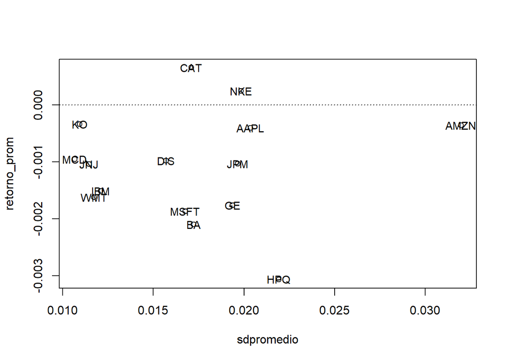

```r
plot(sdpromedio, retorno_prom)
text(sdpromedio, retorno_prom, labels =colnames(MRetornos), cex = 0.9)
abline(h = 0, lty = 3)
```

A continuación calcularé los retornos mensuales del portafolio conformado por estas acciones, con los pesos mencionados anteriormente y además graficaremos estos retornos en un histograma para analizar la normalidad de estos.

```r
#Portafolio
#Retornos mensuales del portafolio
m_return_porfolio <- Return.portfolio(MRetornos, weights =c(0.04, 0.04, 0.01, 0.3,
                                                            0.04, 0.02, 0.02,0.04,
                                                            0.04, 0.04, 0.04, 0.04,
                                                            0.01, 0.3, 0.02))
m_return_porfolio
```

```
##            portfolio.returns
## 2000-12-31      -0.013066000
## 2001-01-31       0.004570803
## 2001-02-28      -0.018353762
## 2001-03-31       0.003279518
## 2001-04-30      -0.002635778
## 2001-05-31       0.006466727
## 2001-06-30      -0.007236088
## 2001-07-31       0.018900541
## 2001-08-31       0.006824716
## 2001-09-30       0.019776867
##        ...
## 2022-03-31      -0.016245142
## 2022-04-30      -0.022272539
## 2022-05-31       0.006702216
## 2022-06-30      -0.015486478
## 2022-07-31       0.032670391
## 2022-08-31      -0.011759763
## 2022-09-30      -0.057320805
## 2022-10-31      -0.010981818
## 2022-11-30       0.019686702
## 2022-12-31      -0.002578419
```

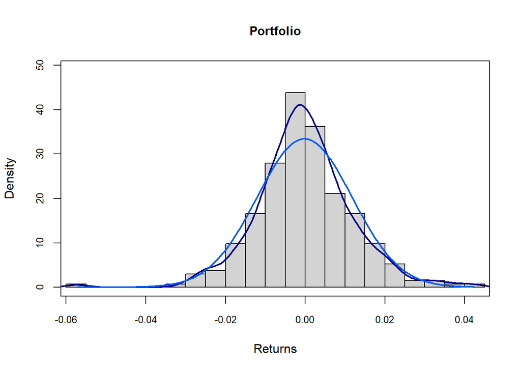

```r
chart.Histogram(m_return_porfolio,  breaks = "FD",
                 main = "Portfolio", methods = c("add.density", "add.normal"),
                border.col = "black",
                element.color = "black",
                 note.color = "black")
```

Esta es una forma simple de analizar la normalidad de los retornos ya que existen herramientas que nos podrían ayudar más para este análisis como lo son la simetría, la curtosis, el Test de Jarque Bera, entre otros, pero en esta ocasión no profundizaré aquellos temas.

Para continuar con nuestro análisis podemos decir que a simple vista los retornos mensuales del portafolio, de acuerdo a las asignaciones de inversión, no muestran una gran diferencia a lo que es una distribución normal. La distribución normal de los retornos está representada por la Campana de Gauss de color azul claro y la densidad de nuestros retornos de color azul oscuro. Las colas de esta distribución a simple vista no posee gran peso y la simetría de la distribució no varía en grandes proporciones. Es más, la distribución de nuestros datos se asemeja bastante a lo que es una normal.

Siguiendo con los calculos relacionados al análisis de portafolio, el siguiente paso a realizar será calcular el retorno promedio mensual del portafolio, calcular la matriz de varianzas y covarianzas de los activos para calcular de esta forma, su desviación estandar mensual promedio, que es la medida por la cual se mide el riesgo de un activo financiero.

```r
#Retorno promedio mensual del portafolio
weights <-c(0.04, 0.04, 0.02, 0.3, 0.04, 0.02, 0.02,0.04,0.04, 0.04, 0.04, 0.04,
            0.01, 0.3, 0.02)
weights <- as.matrix(weights)
retorno_prom <- as.matrix(retorno_prom)
mean_return_monthly <- t(weights) %*% retorno_prom
mean_return_monthly
```

```
##               [,1]
## [1,] -0.0001866302
```

```r
#Matriz de covarianzas
matriz_cov <- cov(MRetornos)
matriz_cov
```

```
##              AMZN         AAPL           BA          CAT          DIS
## AMZN 1.022312e-03 2.242204e-04 1.526985e-04 8.794166e-05 1.001438e-04
## AAPL 2.242204e-04 4.144046e-04 1.022938e-04 7.146638e-05 1.096271e-04
## BA   1.526985e-04 1.022938e-04 2.965365e-04 1.014678e-04 9.507126e-05
## CAT  8.794166e-05 7.146638e-05 1.014678e-04 2.920422e-04 1.110188e-04
## DIS  1.001438e-04 1.096271e-04 9.507126e-05 1.110188e-04 2.461915e-04
## GE   1.254524e-04 1.009133e-04 1.270758e-04 1.567749e-04 1.409113e-04
## HPQ  1.110849e-04 1.205724e-04 8.543255e-05 1.066331e-04 1.131791e-04
## IBM  1.276105e-04 7.654537e-05 6.208456e-05 7.839670e-05 7.439780e-05
## JNJ  1.699109e-05 3.563254e-05 7.460109e-05 6.355848e-05 7.080736e-05
## JPM  1.705226e-04 1.198153e-04 1.472995e-04 1.294674e-04 1.401789e-04
## KO   2.689011e-05 3.623877e-05 6.632557e-05 6.769778e-05 6.872666e-05
## MCD  7.644680e-05 5.499781e-05 6.146341e-05 4.874382e-05 4.778695e-05
## MSFT 1.431784e-04 1.311662e-04 8.985698e-05 8.248588e-05 9.023699e-05
## NKE  1.142502e-04 9.756465e-05 8.016934e-05 8.442433e-05 9.572177e-05
## WMT  3.444185e-05 7.158726e-05 6.377420e-05 5.549833e-05 7.472114e-05
##                GE          HPQ          IBM          JNJ          JPM
## AMZN 1.254524e-04 1.110849e-04 1.276105e-04 1.699109e-05 1.705226e-04
## AAPL 1.009133e-04 1.205724e-04 7.654537e-05 3.563254e-05 1.198153e-04
## BA   1.270758e-04 8.543255e-05 6.208456e-05 7.460109e-05 1.472995e-04
## CAT  1.567749e-04 1.066331e-04 7.839670e-05 6.355848e-05 1.294674e-04
## DIS  1.409113e-04 1.131791e-04 7.439780e-05 7.080736e-05 1.401789e-04
## GE   3.745891e-04 1.530095e-04 6.686349e-05 1.021357e-04 1.897693e-04
## HPQ  1.530095e-04 4.806547e-04 9.789678e-05 6.152804e-05 1.513757e-04
## IBM  6.686349e-05 9.789678e-05 1.464393e-04 3.756764e-05 1.068946e-04
## JNJ  1.021357e-04 6.152804e-05 3.756764e-05 1.312895e-04 7.029781e-05
## JPM  1.897693e-04 1.513757e-04 1.068946e-04 7.029781e-05 3.863731e-04
## KO   8.798792e-05 6.855018e-05 5.040261e-05 6.924152e-05 8.244070e-05
## MCD  4.026240e-05 4.815973e-05 5.358072e-05 4.177994e-05 6.545701e-05
## MSFT 1.223038e-04 1.388069e-04 9.765820e-05 5.894978e-05 1.134464e-04
## NKE  5.810740e-05 7.923246e-05 5.987022e-05 3.723039e-05 1.127020e-04
## WMT  6.837636e-05 5.300325e-05 4.691556e-05 6.173430e-05 6.327594e-05
##                KO          MCD         MSFT          NKE          WMT
## AMZN 2.689011e-05 7.644680e-05 1.431784e-04 1.142502e-04 3.444185e-05
## AAPL 3.623877e-05 5.499781e-05 1.311662e-04 9.756465e-05 7.158726e-05
## BA   6.632557e-05 6.146341e-05 8.985698e-05 8.016934e-05 6.377420e-05
## CAT  6.769778e-05 4.874382e-05 8.248588e-05 8.442433e-05 5.549833e-05
## DIS  6.872666e-05 4.778695e-05 9.023699e-05 9.572177e-05 7.472114e-05
## GE   8.798792e-05 4.026240e-05 1.223038e-04 5.810740e-05 6.837636e-05
## HPQ  6.855018e-05 4.815973e-05 1.388069e-04 7.923246e-05 5.300325e-05
## IBM  5.040261e-05 5.358072e-05 9.765820e-05 5.987022e-05 4.691556e-05
## JNJ  6.924152e-05 4.177994e-05 5.894978e-05 3.723039e-05 6.173430e-05
## JPM  8.244070e-05 6.545701e-05 1.134464e-04 1.127020e-04 6.327594e-05
## KO   1.193985e-04 4.342419e-05 5.861931e-05 4.869854e-05 4.911599e-05
## MCD  4.342419e-05 1.135973e-04 4.627979e-05 5.337617e-05 4.953291e-05
## MSFT 5.861931e-05 4.627979e-05 2.809811e-04 8.790764e-05 5.449210e-05
## NKE  4.869854e-05 5.337617e-05 8.790764e-05 3.937160e-04 6.083994e-05
## WMT  4.911599e-05 4.953291e-05 5.449210e-05 6.083994e-05 1.375643e-04
```

```r
#Desviación estandar promedio mensual del portafolio
mean_desv_st <- sqrt(t(weights) %*% matriz_cov %*% weights)
mean_desv_st
```

```
##            [,1]
## [1,] 0.01159449
```

| Medidas | Valores |
| --- | --- |
| Retorno | -0.00019% |
| Desv. Estandar | 0.012 |

Como resultado tenemos un retorno promedio mensual del portafolio de -0.00019 asociado a 0.012 de riesgo promedio mensual. Lo cual es un retorno muy bajo, casi cercano a 0.No es algo positivo y no es algo que esperaba. Si una tasa libre de riesgo rinde más y por seguro que si, no tendría sentido invertir en este portafolio.

```r
#Sharpe promedio mensual del portafolio
Sharpe <- SharpeRatio(m_return_porfolio, Rf=0)
Sharpe
```

```
##                               portfolio.returns
## StdDev Sharpe (Rf=0%, p=95%):       -0.01420371
## VaR Sharpe (Rf=0%, p=95%):          -0.00880885
## ES Sharpe (Rf=0%, p=95%):           -0.00606024
```

Así mismo, el rendimiento promedio mensual de la cartera medido a través del Ratio de Sharpe nos da -0.014% con una tasa libre de riesgo de 0% de rentabilidad, es decir, que si la tasa libre de riesgo tuviese un rendimiento mayor, nuestro portafolio tendría un rendimiento peor!

A continuación veremos el mismo indicador pero anualizado.

```r
#Retorno anual promedio del portafolio, desv. estandar promedio anual y Sharpe promedio anual con Rf= 0
table.AnnualizedReturns(m_return_porfolio)
```

|  | portfolio.returns |
| --- | --- |
| Annualized Return | -0.0029 |
| Annualized Std Dev | 0.0414 |
| Annualized Sharpe (Rf=0%) | -0.0697 |

Como podemos ver, los resultados no cambian mucho, son igual de malos.

Continuando con el análisis seguiremos con el calculo del portafolio óptimo, función que nos brinda el paquete “tseries”.

```r
#Ya obtenido lo anterior procederemos a calcular el portafolio optimo
op_portfolio <- portfolio.optim(MRetornos)
op_portfoliopm <- op_portfolio$pm #retorno
op_portfoliops <- op_portfolio$ps #desviación estandar
```

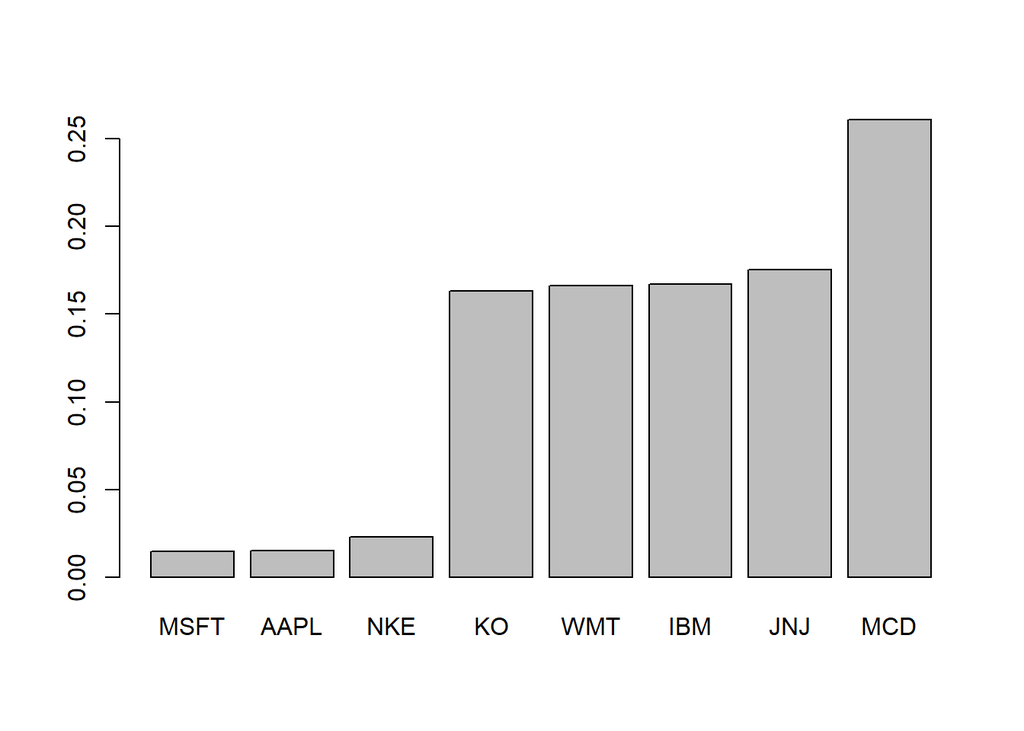

```r
#weights
op_portfoliopw <- op_portfolio$pw
names(op_portfoliopw) <- colnames(MRetornos)
#Selecciono las asignaciones mayores a 1 y las gráfico
opt_weights <- op_portfoliopw[op_portfoliopw >= 0.01]
barplot(sort(opt_weights))
```

```r
op_portfoliopm
```

```
## [1] -0.001075597
```

```r
op_portfoliops
```

```
## [1] 0.008066804
```

Sin embargo, aún teniendo un portafolio óptimo, el retorno de este es levemente negativo, con una desviación estandar de un 0.008%

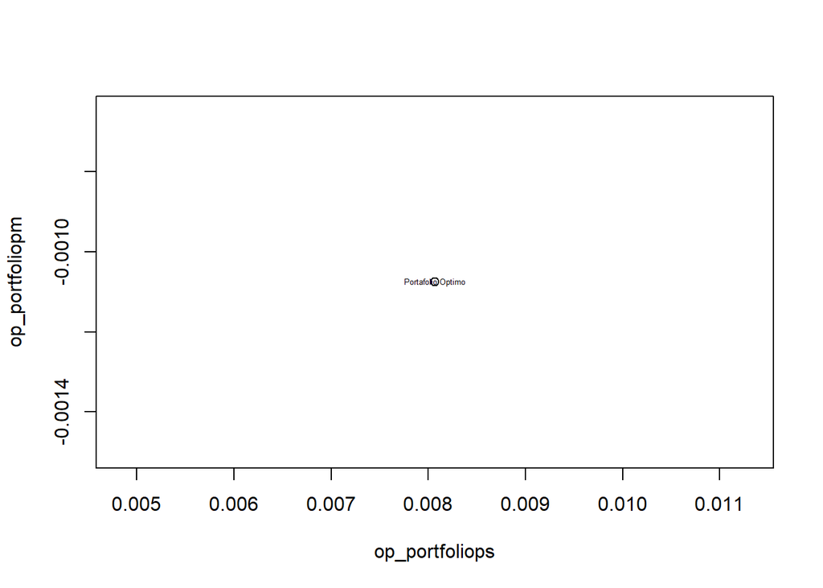

```r
plot(op_portfoliops, op_portfoliopm)
text(op_portfoliops, op_portfoliopm, labels ="Portafolio Optimo", cex = 0.4)
abline(h = 0, lty = 3)
```